# Matplotlib의 여러가지 플롯

Matplotlib는 기본적인 라인 플롯 이외에도 다양한 챠트/플롯 유형을 지원한다.

## 바 차트

x 데이터가 카테고리 값인 경우에는 `bar` 명령과 `barh` 명령으로 바 차트(bar chart) 시각화를 할 수 있다.  
가로 방향으로 바 차트를 그리려면 `barh` 명령을 사용한다.

자세한 내용은 다음 웹사이트를 참조한다.

- http://matplotlib.org/api/pyplot_api.html#matplotlib.pyplot.bar
- http://matplotlib.org/api/pyplot_api.html#matplotlib.pyplot.barh

```python
import matplotlib as mpl
import matplotlib.pylab as plt
import koreanize_matplotlib
import numpy as np
```

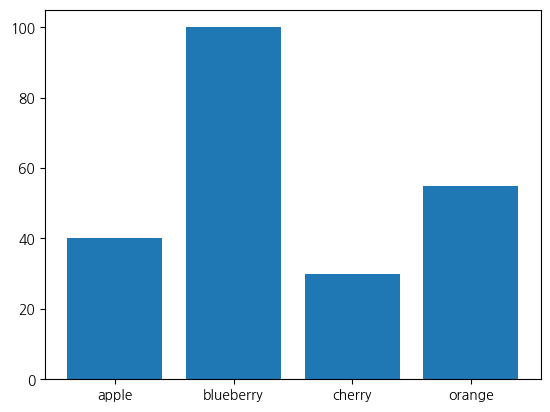

```python
fruits = ['apple', 'blueberry', 'cherry', 'orange']
counts = [40, 100, 30, 55]
plt.bar(fruits, counts)
plt.show()
```

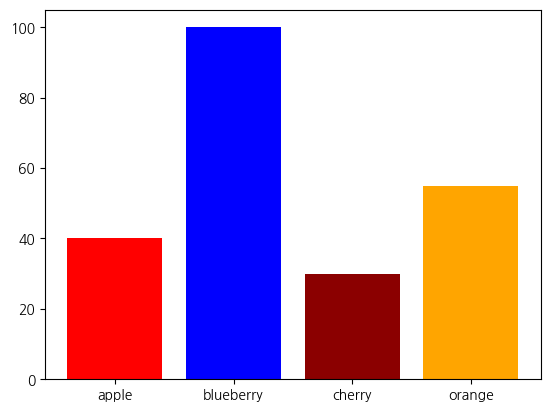

```python
colors = ['red', 'blue', 'darkred', 'orange']
plt.bar(fruits, counts, color=colors)
plt.show()
```

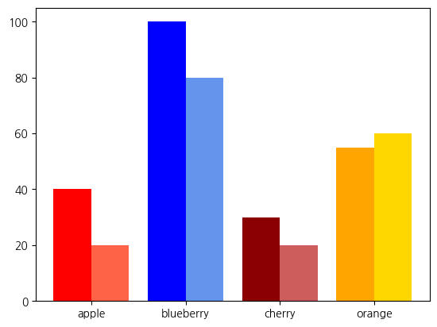

```python
# 다중 막대 차트
counts2 = [20, 80, 20, 60]
colors2 = ['tomato', 'cornflowerblue', 'indianred', 'gold']

idx = np.arange(len(counts))

width = 0.4

plt.bar(idx, counts, width, color=colors)
# plt.bar(x=idx, height=counts, width=width, color=colors)
plt.bar(idx + width, counts2, width, color=colors2)

plt.xticks(idx + width / 2, fruits)
plt.show()
```

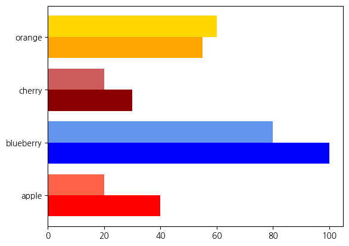

```python
# 가로 막대 차트
# 요인이 많거나 값이 크면 보기 어렵고, 라벨명이 길어도 괜찮음
# 다중 막대 차트
counts2 = [20, 80, 20, 60]
colors2 = ['tomato', 'cornflowerblue', 'indianred', 'gold']
# ind = np.arange(len(counts))
width = 0.4
plt.barh(idx, counts, width, color=colors)
# plt.bar(x=idx, height=counts, width=width, color=colors)
plt.barh(idx + width, counts2, width, color=colors2)
plt.yticks(idx + width / 2, fruits)
plt.show()
```

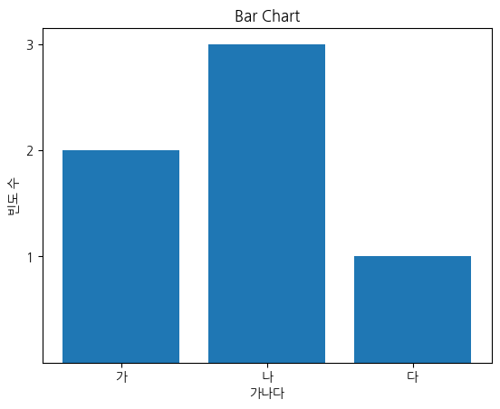

```python
y = [2, 3, 1]
x = np.arange(len(y))

xlabel = ['가', '나', '다']

plt.title("Bar Chart")
plt.bar(x, y)

plt.xticks(x, xlabel)
plt.yticks(sorted(y))

plt.xlabel("가나다")
plt.ylabel("빈도 수")

plt.show()
```

`xerr` 인수나 `yerr` 인수를 지정하면 에러 바(error bar)를 추가할 수 있다.

다음 코드에서 `alpha`는 투명도를 지정한다. 0이면 완전 투명, 1이면 완전 불투명이다.

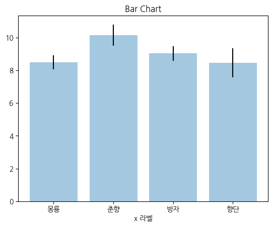

```python
np.random.seed(0)

people = ['몽룡', '춘향', '방자', '향단']
y_pos = np.arange(len(people))

performance = 3 + 10 * np.random.rand(len(people))
error = np.random.rand(len(people))

plt.title("Bar Chart")
plt.bar(y_pos, performance, yerr=error, alpha=0.4) # 변경
plt.xticks(y_pos, people) # 변경

plt.xlabel('x 라벨')
plt.show()
```

```python
plt.barh?
```

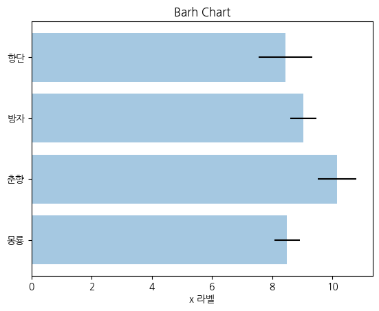

```python
# 가로 막대로 바꿔보자.
np.random.seed(0)

people = ['몽룡', '춘향', '방자', '향단']
y_pos = np.arange(len(people)) # x 값

performance = 3 + 10 * np.random.rand(len(people)) # y값
error = np.random.rand(len(people)) # 에러 랜덤 입력

plt.title("Barh Chart")
plt.barh(y_pos, performance, xerr=error, alpha=0.4)

plt.yticks(y_pos, people)
plt.xlabel('x 라벨')
plt.show()
```

## 스템 플롯

바 차트와 유사하지만 폭(width)이 없는 스템 플롯(stem plot)도 있다.  
주로 이산 확률 함수나 자기상관관계(auto-correlation)를 묘사할 때 사용된다.

- http://matplotlib.org/api/pyplot_api.html#matplotlib.pyplot.stem

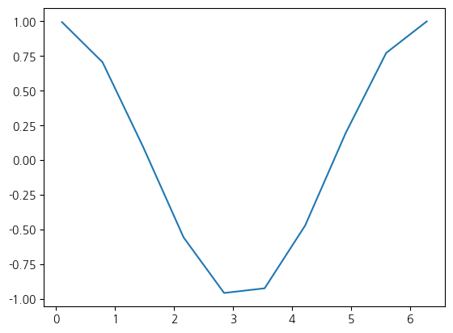

```python
X = np.linspace(0.1, 2*np.pi, 10)
plt.plot(X, np.cos(X))
plt.show()
```

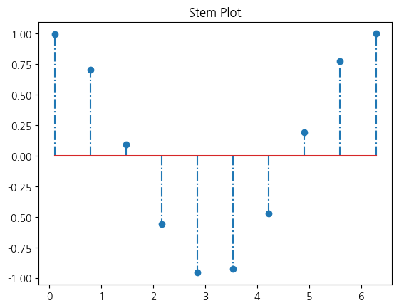

```python
x = np.linspace(0.1, 2*np.pi, 10)

plt.title("Stem Plot")
plt.stem(x, np.cos(x), '-.')
plt.show()
```

## 파이 차트

카테고리 별 값의 상대적인 비교를 해야 할 때는 `pie` 명령으로 파이 차트(pie chart)를 그릴 수 있다.  
파이 차트를 그릴 때는 윈의 형태를 유지할 수 있도록 다음 명령을 실행해야 한다.

```
plt.axis('equal')
```

자세한 내용은 다음을 참조한다.

- http://matplotlib.org/api/pyplot_api.html#matplotlib.pyplot.pie

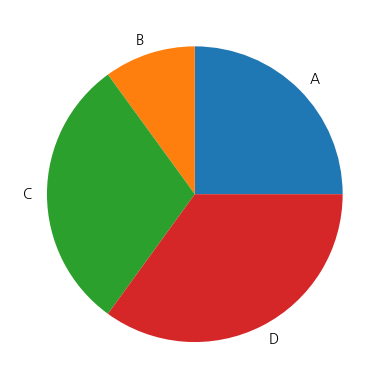

```python
ratio = [0.25, 0.1, 0.3, 0.35]
grade = ['A', 'B', 'C', 'D']
plt.pie(ratio, labels=grade)
plt.show()
```

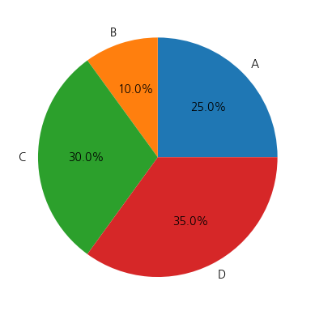

```python
plt.pie(ratio, labels=grade, autopct='%.1f%%')
plt.show()
```

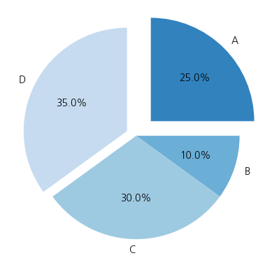

```python
# 스타일
cmap = plt.get_cmap('tab20c') # theme
colors = cmap(np.arange(len(ratio)) % cmap.N)
# colors = ['blue', 'green', 'cyan', 'orange']

explode = (0.2, 0, 0, 0.1) # 분리시키는 정도
plt.pie(ratio, labels=grade, autopct='%.1f%%', startangle=90, counterclock=False, colors=colors, explode=explode)
plt.show()
```

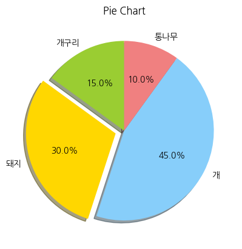

```python
labels = ['개구리', '돼지', '개', '통나무']
sizes = [15, 30, 45, 10]
colors = ['yellowgreen', 'gold', 'lightskyblue', 'lightcoral']
explode = (0, 0.1, 0, 0)

plt.title("Pie Chart")
plt.pie(sizes, explode=explode, labels=labels, colors=colors,
        autopct='%1.1f%%', shadow=True, startangle=90)
plt.axis('equal')
plt.show()
```

## 박스 플롯

```python
score = [21, 78, 89, 57, 75, 99, 98, 87, 70, 65, 88, 95, 94, 55, 93, 83, 78, 62, 65, 77, 80]
```

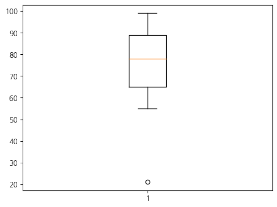

```python
plt.boxplot(score)
plt.show()
```

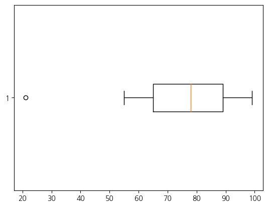

```python
# 가로로 그리기
plt.boxplot(score, vert=False)
plt.show()
```

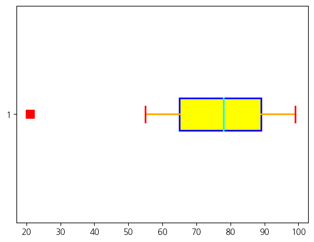

```python
bp = plt.boxplot(score, vert=False, patch_artist=True)

for box in bp['boxes']:
    box.set(color='blue', linewidth=2, facecolor = 'yellow')

for cap in bp['caps']:
    cap.set(color='red', linewidth=2)

for whisker in bp['whiskers']:
    whisker.set(color='orange', linewidth=2)

for median in bp['medians']:
    median.set(color='cyan', linewidth=2)

for flier in bp['fliers']:
    flier.set(marker='s', markerfacecolor='r', markersize=10, markeredgecolor='r')
plt.show()
```

```python
bp
```

[output not shown]

```python
data1 = np.random.normal(0, 1, 1000)
data2 = np.random.normal(1, 1, 1000)
```

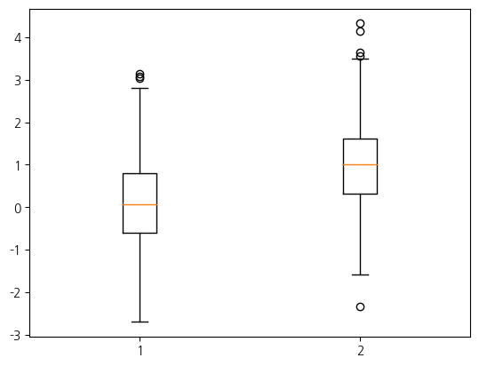

```python
plt.boxplot([data1, data2])
plt.show()
```

## 히스토그램

히스토그램을 그리기 위한 `hist` 명령도 있다.  
`hist` 명령은 `bins` 인수로 데이터를 집계할 구간 정보를 받는다.  
반환값으로 데이터 집계 결과를 반환한다.

- http://matplotlib.org/api/pyplot_api.html#matplotlib.pyplot.hist

```python
plt.hist?
```

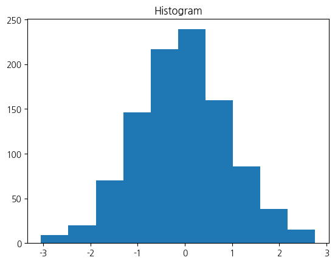

```python
np.random.seed(0)
x = np.random.randn(1000)

plt.title("Histogram")
# plt.hist(x, bins=10)
arrays, bins, patches = plt.hist(x, bins=10)
plt.show()
```

```python
arrays # 밀도
```

```
array([  9.,  20.,  70., 146., 217., 239., 160.,  86.,  38.,  15.])
```

```python
bins
```

```
array([-3.04614305, -2.46559324, -1.88504342, -1.3044936 , -0.72394379,
       -0.14339397,  0.43715585,  1.01770566,  1.59825548,  2.1788053 ,
        2.75935511])
```

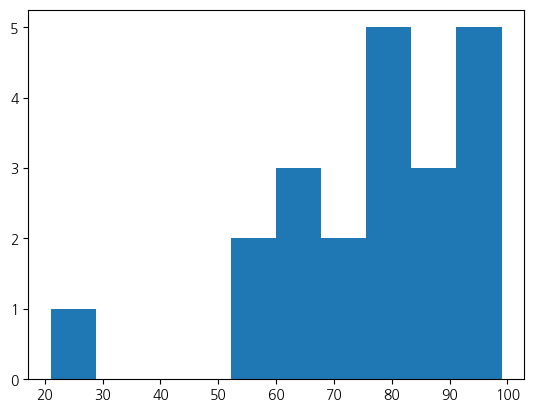

```python
score = [21, 78, 89, 57, 75, 99, 98, 87, 70, 65, 88, 95, 94, 55, 93, 83, 78, 62, 65, 77, 80]
plt.hist(score)
plt.show()
```

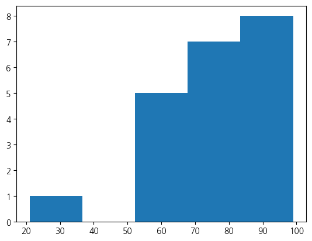

```python
# bins 수 설정
plt.hist(score, bins=5)
plt.show()
```

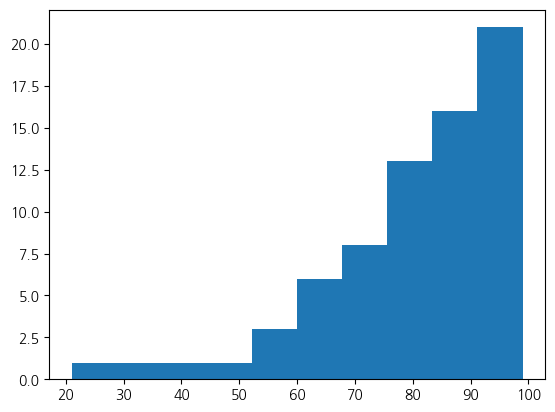

```python
# 누적 히스토그램
plt.hist(score, cumulative=True)
plt.show()
```

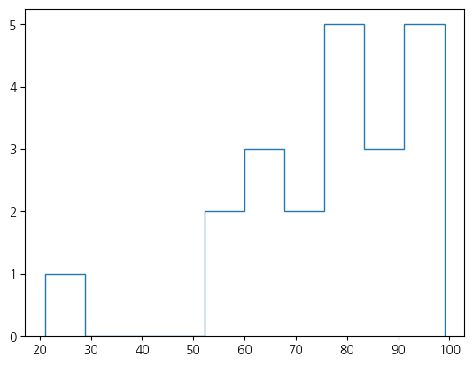

```python
# 모양 바꾸기
plt.hist(score, histtype='step')
plt.show()
```

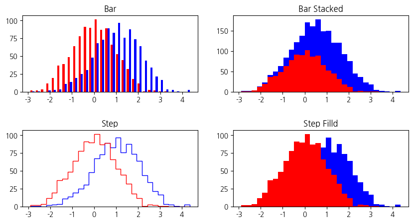

```python
# 다양한 스타일
data1 = np.random.normal(0, 1, 1000)
data2 = np.random.normal(1, 1, 1000)

# bar, barstacked, step, step filld
fig, axs = plt.subplots(2, 2, figsize=(10, 5))

axs[0,0].hist([data1, data2] , bins=30, color=['red', 'blue'], histtype='bar'  )
axs[0,0].set_title('Bar')

axs[0,1].hist([data1, data2] , bins=30, color=['red', 'blue'], histtype='barstacked'  )
axs[0,1].set_title('Bar Stacked')

axs[1,0].hist([data1, data2] , bins=30, color=['red', 'blue'], histtype='step'  )
axs[1,0].set_title('Step')

axs[1,1].hist([data1, data2] , bins=30, color=['red', 'blue'], histtype='stepfilled'  )
axs[1,1].set_title('Step Filld')

fig.subplots_adjust(hspace=0.5) # 서브플롯 간격 띄우기

plt.show()
```

## 스캐터 플롯

2차원 데이터 즉, 두 개의 실수 데이터 집합의 상관관계를 살펴보려면 `scatter` 명령으로 스캐터 플롯을 그린다.  
스캐터 플롯의 점 하나의 위치는 데이터 하나의 x, y 값이다.

- http://matplotlib.org/api/pyplot_api.html#matplotlib.pyplot.scatter

```python
data1 = np.random.normal(0, 1, 1000)
data2 = np.random.normal(1, 1, 1000)
```

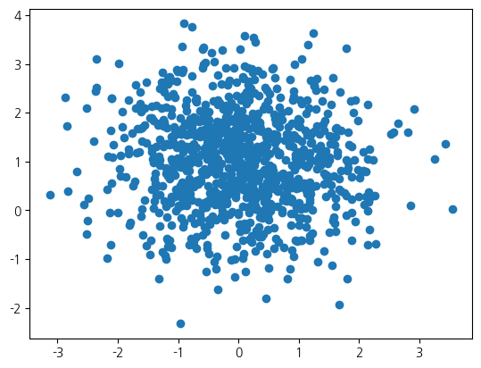

```python
plt.scatter(data1, data2)
plt.show()
```

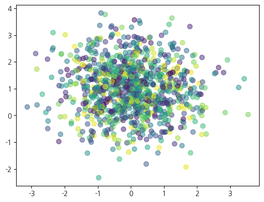

```python
size = 50
colors = np.random.rand(1000)
plt.scatter(data1, data2, s=size, c=colors, alpha=0.5)
plt.show()
```

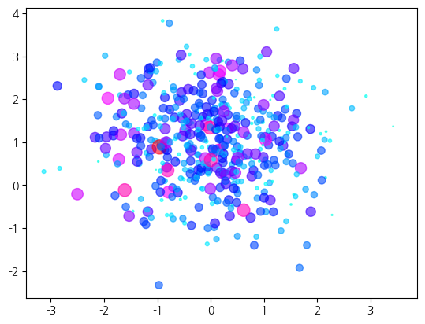

```python
data3 = np.random.normal(1, 50, 1000)
plt.scatter(data1, data2, s=data3, c=data3, alpha=0.6, cmap='hsv')
plt.show()
```

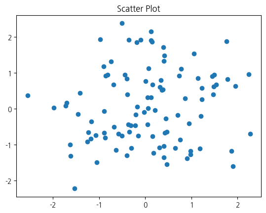

```python
np.random.seed(0)

X = np.random.normal(0, 1, 100)
Y = np.random.normal(0, 1, 100)

plt.title("Scatter Plot")
plt.scatter(X, Y)
plt.show()
```

데이터가 2차원이 아니라 3차원 혹은 4차원인 경우에는 점 하나의 크기 혹은 색깔을 이용하여 다른 데이터 값을 나타낼 수도 있다.  
이런 차트를 버블 차트(bubble chart)라고 한다. 크기는 `s` 인수로 색깔은 `c` 인수로 지정한다.

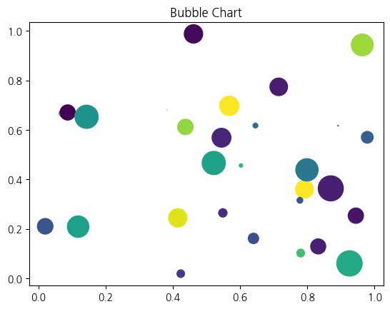

```python
N = 30
np.random.seed(0)

x = np.random.rand(N)
y = np.random.rand(N)
color = np.random.rand(N)
size = np.pi * (15 * np.random.rand(N))**2 # 볼륨의미하는 데이터, 원 넓이, pi*r^2

plt.title("Bubble Chart")
plt.scatter(x, y, s=size, c=color) # 색에 랜덤값 입력
plt.show()
```